# Data Science for Public Policy

Nathalie Kirsch and Vanaaisha Pamnani

### PPOL 670 | Assignment 4

### Data Visualization, Markdown, and Git

This assignment is stored on the following [Github repository](https://github.com/nakirsch/PPOL670_Assignment04/).

The four data visualizations in this document were created using the following source:

[72 Small and Medium-Size Cities Built Environment and Health Equity Dataset](https://datacatalog.urban.org/dataset/72-small-and-medium-size-cities-built-environment-and-health-equity-dataset)

This Urban Institute data set includes summary demographics, economic and housing demographics, and health indicators for 72 small and medium-size cities across the country. The research team interviewed stakeholders from 19 of the cities included in the data set. The remaining 53 cities were selected as “peer” cities that shared one for more of the following characteristics with many of the 19 cities: similar city type (suburban, central city, etc.), range of population (small or medium-sized), and location within the same metropolitan region or the same state/part of the country. All collected data are for the most recent year available as of May 22, 2020.

We used the Urban Institute’s data set to analyze population trends, unemployment rates, and opioid overdose deaths across U.S. regions. All of these factors are important for crafting policies that address economic and social inequities across the United States.

```r
library(tidyverse)
library(ggplot2)
library(readxl)
library(ggthemes)
```

```r
data <- read_xlsx(path = "data/Built Environment Health Equity Data Table.xlsx", sheet = "City data", range = "A2:AU72") %>%
  janitor::clean_names()
```

1. Data Visualization #1: Percent Change in Population From 2013 to 2018 By Region

Overall, we found that population increased across all regions from 2013 to 2018. However, we can see that both the South and West regions experienced the largest percentage increases in population, while the Midwest and Northeast experienced much smaller population gains. This provides insight into potential economic growth within these regions and the possible need to reallocate more resources to accommodate this population growth. Additionally, it is possible that areas experiencing smaller population growth increases could posess economic factors that make them less desirable for people to live there.

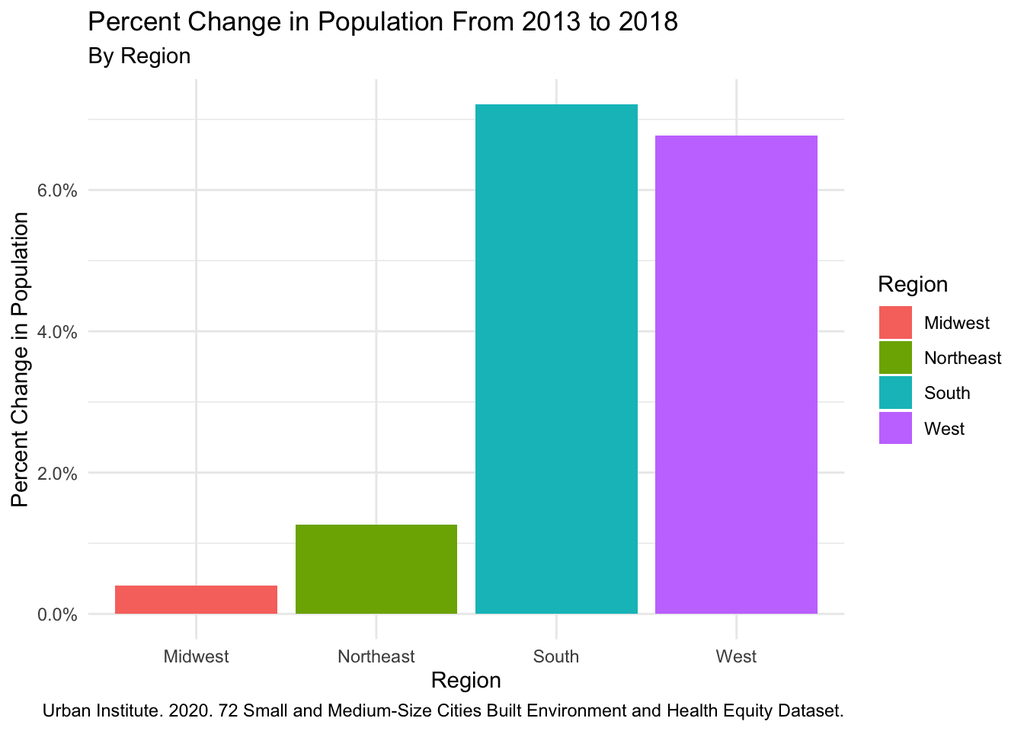

```r
data %>%
  mutate(percent_pop_change = ((population_2018 - population_2013)/population_2013)) %>%
  group_by(region) %>%
  summarize(mean_pop_change = mean(percent_pop_change)) %>%
  ggplot(mapping = aes(x = region, y = mean_pop_change, fill = region, ymin = 0)) +
  geom_col() +
  labs (
    title = "Percent Change in Population From 2013 to 2018",
    subtitle = "By Region",
    x = "Region",
    y = "Percent Change in Population",
    caption = "Urban Institute. 2020. 72 Small and Medium-Size Cities Built Environment and Health Equity Dataset.",
  ) +
  scale_fill_discrete(name="Region") +
  scale_y_continuous(labels = scales::percent) +
  theme_minimal()
```

2. Data Visualization #2: The Total Unemployment Rate by Region

Overall, average unemployment hovers between 5 to 10% for each region. We can see that the city with the highest unemployment rate (approximately 15%) is located in the Midwest region. This region also has a large variance in unemployment rates, whereas the Western region has a maximum unemployment rate of 9% and a smaller variance. These discrepancies indicate that economic disparities are not consistent across all regions, and may indicate that we need more targeted programming in certain regions to close these unemployment gaps.

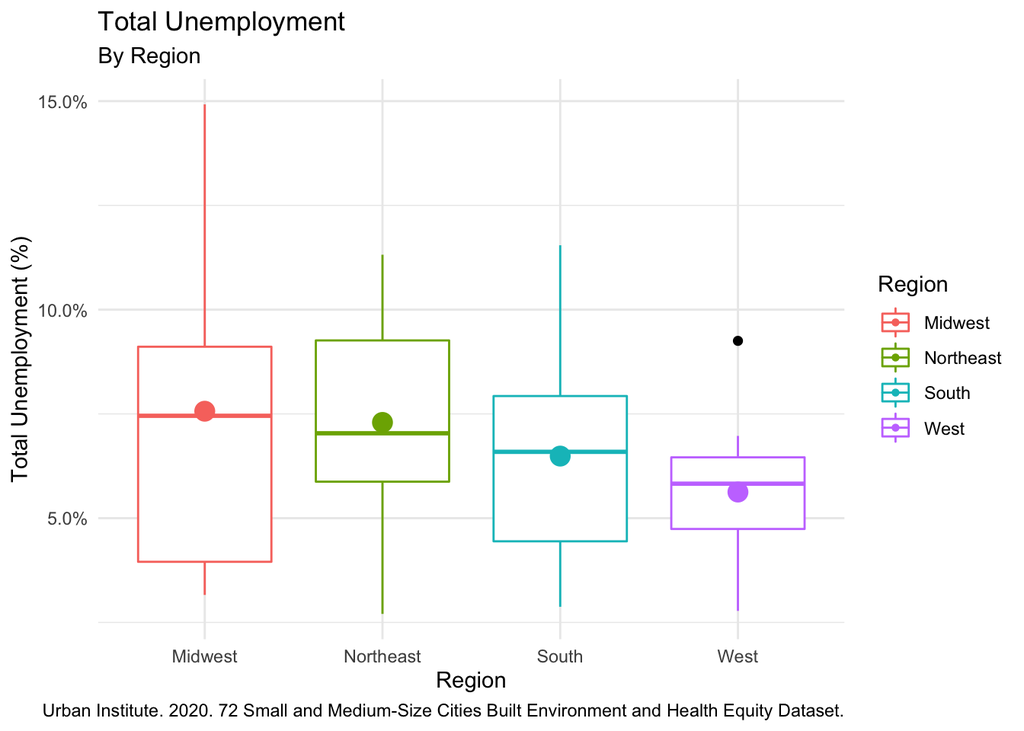

```r
data %>%
  mutate(unemployment = total_unemployment_percent/100) %>%
  ggplot(aes(region, unemployment , color = region, stroke = 5, ymin = 0)) +
    geom_boxplot(outlier.colour="black", outlier.shape=16,outlier.size=2, notch=FALSE) +
    stat_summary(fun.y=mean, geom="point", shape=16) +
     scale_y_continuous(labels = scales::percent) +
     labs(
       x = "Region",
       y = "Total Unemployment (%)",
       title = "Total Unemployment",
       subtitle = "By Region",
       caption = "Urban Institute. 2020. 72 Small and Medium-Size Cities Built Environment and Health Equity Dataset.",
       color = "Region"
     ) +
  theme_minimal()
```

3. Data Visualization #3: The Relationship between Population Trends and Total Unemployment By Region

Overall, unemployment seems to be higher in regions and cities where population is stagnated or decreasing. We can also see that the highest rates of unemployment are located in the Midwest. This visualization complements the previous two graphs as it provides us more details on how population trends vary with unemployment rates. This visualization also indicates that policy makers would likely need to focus unemployment reduction efforts in areas that are decreasing in population.

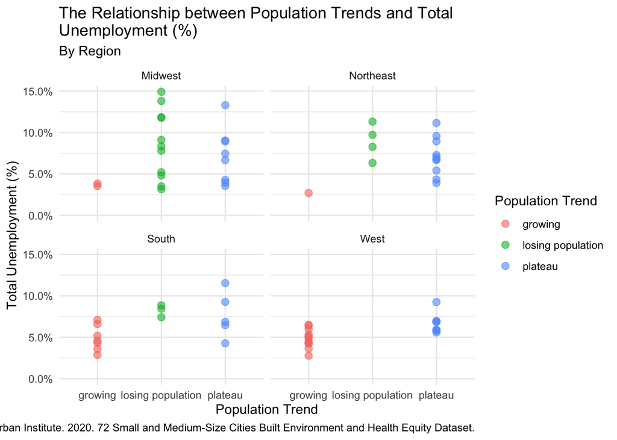

```r
data %>%
  mutate(unemployment = total_unemployment_percent/100) %>%
  ggplot(aes(population_trend, unemployment, color = population_trend, ymin = 0)) +
  geom_point(alpha = 0.6, size = 2.5) +
  facet_wrap(~region) +
  scale_y_continuous(labels = scales::percent) +
       labs(
       x = "Population Trend",
       y = "Total Unemployment (%)",
       title = "The Relationship between Population Trends and Total
Unemployment (%)",
       subtitle = "By Region",
       caption = "Urban Institute. 2020. 72 Small and Medium-Size Cities Built Environment and Health Equity Dataset.",
       color = "Population Trend"
       ) +
  theme_minimal()
```

4. Data Visualization #4: Relationship Between Unemployment and Opioid Overdose Deaths By Region

When comparing average unemployment rates from 2014 to 2018 to the number of opioid overdose deaths per 100,000 in 2017, it appears that there is no significant relationship between these variables except for in the Midwest. It is worth noting, however, that the strong relationship observed in the Midwest may be heavily driven by Dayton, Ohio, the outlier city labeled in the figure below. As opioid deaths have become a national concern over the past few years, this data can provide surface-level insights as to where opioid reduction programs and rehabiliation services may need to be targeted.

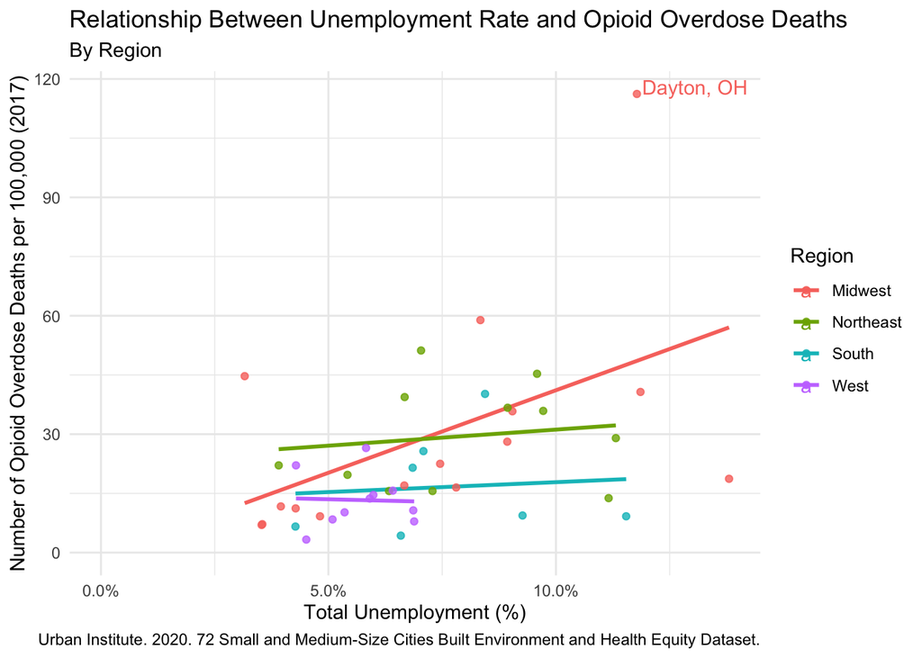

```r
data %>%
  filter(!opioid_overdose_deaths == "NA") %>%
  mutate(opioid_overdose_deaths = as.numeric(opioid_overdose_deaths),
         unemployment = total_unemployment_percent/100) %>%
  group_by(region) %>%
  ggplot(mapping = aes(x = unemployment, y = opioid_overdose_deaths, xmin = 0, ymin = 0, color = region)) +
  geom_smooth(method = "lm", se = FALSE, alpha = 0.3) +
  geom_point(alpha = 0.8) +
  geom_text(aes(label=ifelse(opioid_overdose_deaths>115,as.character(city),'')), hjust=-0.05, vjust=0) +
  labs (
    title = "Relationship Between Unemployment Rate and Opioid Overdose Deaths",
    subtitle = "By Region",
    x = "Total Unemployment (%)",
    y = "Number of Opioid Overdose Deaths per 100,000 (2017)",
    caption = "Urban Institute. 2020. 72 Small and Medium-Size Cities Built Environment and Health Equity Dataset.",
    color = "Region"
  ) +
  scale_x_continuous(labels = scales::percent) +
  theme_minimal()
```

Stretch Exercise 01

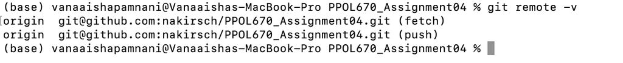

Screenshot of git remote -v